# Predictive Analytics and Modelling

Laban Bore

5/23/2020

**Action Items**

1. Study the blog https://www.statmethods.net/advstats/bootstrapping.html. Fit a multiple linear regression model using all the other predictors to explain the outcome medv A. Construct 95% boostrap confidence intervals for the coefficients of the model; B. Construct 95% boostrap confidence intervals for R-squared and adjusted R-squared in the mode; Hint: See names(summary(fit)) C. Construct 95% boostrap confidence intervals for the coefficients of the model;
2. Using a full multiple linear regression model, a step-wise regression model, a principal components regression, and a partial least squares.

# 1 Introduction

We are going to analyze housing data variables in the suburbs of Boston using multilinear regression model which is an extension of simple linear regression used to predict an outcome variable (y) on the basis of multiple distinct predictor variables (x).

# 2 Methodology

We’ll use Boston dataset in the library `MASS package` which presents housing values in suburbs of Boston.

We will use Bootstrapping method to bootstrap a single statistic eg mean coefficients or vectors from Boston housing data frame.Boot package `boot()` provides various options for bootstrapping and resampling. It function has the format

`bootobject <- boot(data= , statistic= , R=, ...)`

*full multiple linear regression model, a step-wise regression model, a principal components regression, and a partial least squares*.

We choose `Bias-Corrected and Accelerated (BCa)` method to calculate bootstrap confidence intervals

# 3 Results and Analysis

## 3.1 Data Description

The Boston dataset consists of 506 suburbs where 14 variables of interest are measured. The predictor and outcome variables are as follows:

**Outcome variables**

- **medv** median value of owner-occupied homes in $1000s.

**Predictor variables**

- **crim** per capita crime rate by town.
- **zn** proportion of residential land zoned for lots over 25,000 sq.ft.
- **indus** proportion of non-retail business acres per town.
- **chas** Charles River dummy variable (= 1 if tract bounds river; 0 otherwise).
- **nox** nitrogen oxides concentration (parts per 10 million).
- **rm** average number of rooms per dwelling.
- **age** proportion of owner-occupied units built prior to 1940.
- **dis** weighted mean of distances to five Boston employment centres.
- **rad** index of accessibility to radial highways.
- **tax** full-value property-tax rate per $10,000.
- **ptratio** pupil-teacher ratio by town.
- **black** 1000(Bk - 0.63)^2 where Bk is the proportion of blacks by town.
- **lstat** lower status of the population (percent).

The **first 5 rows** of Boston dataset

| crim | zn | indus | chas | nox | rm | age | dis | rad | tax | ptratio | black | lstat | medv |
| --- | --- | --- | --- | --- | --- | --- | --- | --- | --- | --- | --- | --- | --- |
| 0.00632 | 18 | 2.31 | 0 | 0.538 | 6.575 | 65.2 | 4.0900 | 1 | 296 | 15.3 | 396.90 | 4.98 | 24.0 |
| 0.02731 | 0 | 7.07 | 0 | 0.469 | 6.421 | 78.9 | 4.9671 | 2 | 242 | 17.8 | 396.90 | 9.14 | 21.6 |
| 0.02729 | 0 | 7.07 | 0 | 0.469 | 7.185 | 61.1 | 4.9671 | 2 | 242 | 17.8 | 392.83 | 4.03 | 34.7 |
| 0.03237 | 0 | 2.18 | 0 | 0.458 | 6.998 | 45.8 | 6.0622 | 3 | 222 | 18.7 | 394.63 | 2.94 | 33.4 |
| 0.06905 | 0 | 2.18 | 0 | 0.458 | 7.147 | 54.2 | 6.0622 | 3 | 222 | 18.7 | 396.90 | 5.33 | 36.2 |

## 3.2 Fit Multilinear Regression Model

```
Call:
lm(formula = medv ~ ., data = Boston)

Residuals:
    Min      1Q  Median      3Q     Max
-15.595  -2.730  -0.518   1.777  26.199

Coefficients:
              Estimate Std. Error t value Pr(>|t|)
(Intercept)  3.646e+01  5.103e+00   7.144 3.28e-12 ***
crim        -1.080e-01  3.286e-02  -3.287 0.001087 **
zn           4.642e-02  1.373e-02   3.382 0.000778 ***
indus        2.056e-02  6.150e-02   0.334 0.738288
chas         2.687e+00  8.616e-01   3.118 0.001925 **
nox         -1.777e+01  3.820e+00  -4.651 4.25e-06 ***
rm           3.810e+00  4.179e-01   9.116  < 2e-16 ***
age          6.922e-04  1.321e-02   0.052 0.958229
dis         -1.476e+00  1.995e-01  -7.398 6.01e-13 ***
rad          3.060e-01  6.635e-02   4.613 5.07e-06 ***
tax         -1.233e-02  3.760e-03  -3.280 0.001112 **
ptratio     -9.527e-01  1.308e-01  -7.283 1.31e-12 ***
black        9.312e-03  2.686e-03   3.467 0.000573 ***
lstat       -5.248e-01  5.072e-02 -10.347  < 2e-16 ***
---
Signif. codes:  0 '***' 0.001 '**' 0.01 '*' 0.05 '.' 0.1 ' ' 1

Residual standard error: 4.745 on 492 degrees of freedom
Multiple R-squared:  0.7406,    Adjusted R-squared:  0.7338
F-statistic: 108.1 on 13 and 492 DF,  p-value: < 2.2e-16
```

Extract the coefficients of the model

```r
summary(fitFullModel)$coefficients %>% kable() %>% kable_styling(bootstrap_options = c("striped", "hover", "condensed", "responsive", font_size = 7))
```

|  | Estimate | Std. Error | t value | Pr(>\|t\|) |
| --- | --- | --- | --- | --- |
| (Intercept) | 36.4594884 | 5.1034588 | 7.1440742 | 0.0000000 |
| crim | -0.1080114 | 0.0328650 | -3.2865169 | 0.0010868 |
| zn | 0.0464205 | 0.0137275 | 3.3815763 | 0.0007781 |
| indus | 0.0205586 | 0.0614957 | 0.3343100 | 0.7382881 |
| chas | 2.6867338 | 0.8615798 | 3.1183809 | 0.0019250 |
| nox | -17.7666112 | 3.8197437 | -4.6512574 | 0.0000042 |
| rm | 3.8098652 | 0.4179253 | 9.1161402 | 0.0000000 |
| age | 0.0006922 | 0.0132098 | 0.0524024 | 0.9582293 |
| dis | -1.4755668 | 0.1994547 | -7.3980036 | 0.0000000 |
| rad | 0.3060495 | 0.0663464 | 4.6128998 | 0.0000051 |
| tax | -0.0123346 | 0.0037605 | -3.2800091 | 0.0011116 |
| ptratio | -0.9527472 | 0.1308268 | -7.2825106 | 0.0000000 |
| black | 0.0093117 | 0.0026860 | 3.4667926 | 0.0005729 |
| lstat | -0.5247584 | 0.0507153 | -10.3471458 | 0.0000000 |

- Construct 95% *boostrap confidence intervals* for the **coefficients** of the full multiple linear regression model

```
ORDINARY NONPARAMETRIC BOOTSTRAP


Call:
boot(data = Boston, statistic = bs, R = 1000, formula = medv ~
    .)


Bootstrap Statistics :
          original        bias    std. error
t1*   3.645949e+01 -5.694321e-01 7.982630894
t2*  -1.080114e-01  4.457801e-03 0.033046786
t3*   4.642046e-02 -2.453031e-04 0.013322057
t4*   2.055863e-02 -6.521019e-04 0.048354772
t5*   2.686734e+00  7.955767e-02 1.289298289
t6*  -1.776661e+01  2.239080e-01 3.776715275
t7*   3.809865e+00  5.604655e-02 0.822635240
t8*   6.922246e-04 -1.419634e-03 0.015797032
t9*  -1.475567e+00  8.978328e-04 0.213364002
t10*  3.060495e-01 -3.194551e-03 0.060303948
t11* -1.233459e-02 -5.537123e-05 0.002736476
t12* -9.527472e-01  5.168073e-03 0.117901472
t13*  9.311683e-03  1.382382e-04 0.002682305
t14* -5.247584e-01  5.278865e-03 0.095029555
```

[figure not shown]

Plot of Intercept

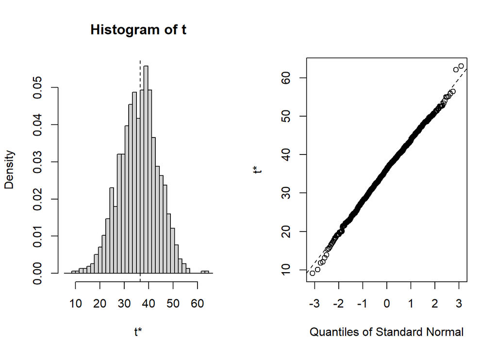

```r
plot(results, index=1, main="Histogram for intercept") # intercept
```

Tabulated results with 95% Bootstrap confidence intervals for the coefficients

| Variables | original | 95% Confidence intervals |
| --- | --- | --- |
| Intercept | 36.4594884 | (21.72, 54.41 ) |
| crim | -0.1080114 | (-0.1611, -0.0351 ) |
| zn | 0.0464205 | ( 0.0201, 0.0759 ) |
| indus | 0.0205586 | (-0.0764, 0.1199 ) |
| chas | 2.6867338 | ( 0.449, 5.415 ) |
| nox | -17.7666112 | (-27.16, -11.45 ) |
| rm | 3.8098652 | ( 2.071, 5.345 ) |
| age | 0.0006922 | (-0.0279, 0.0351 ) |
| dis | -1.4755668 | (-1.927, -1.074 ) |
| rad | 0.3060495 | ( 0.1935, 0.4364 ) |
| tax | -0.0123346 | (-0.0181, -0.0068 ) |
| ptratio | -0.9527472 | (-1.2193, -0.7405 ) |
| black | 0.0093117 | ( 0.0027, 0.0144 ) |
| lstat | -0.5247584 | (-0.7243, -0.3384 ) |

```
ORDINARY NONPARAMETRIC BOOTSTRAP


Call:
boot(data = Boston, statistic = rsquare, R = 1000, formula = medv ~
    .)


Bootstrap Statistics :
     original      bias    std. error
t1* 0.7406427 0.008102689   0.0270066
```

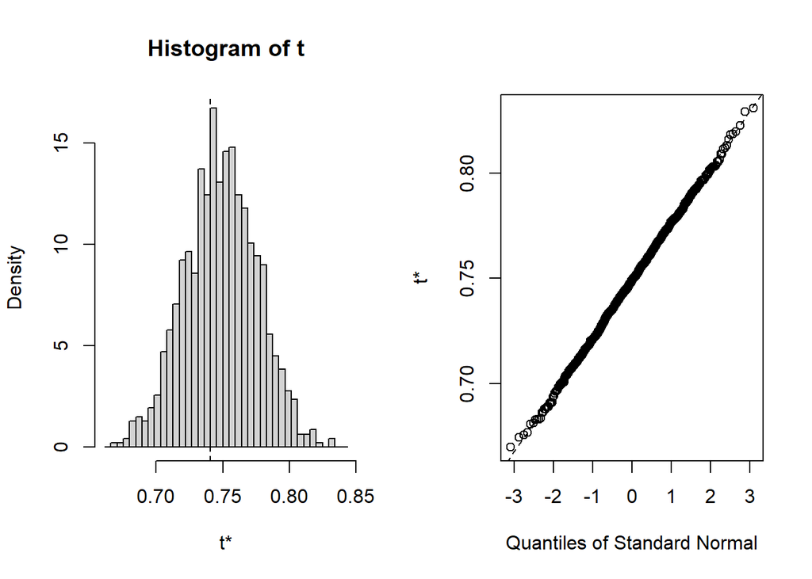

```
BOOTSTRAP CONFIDENCE INTERVAL CALCULATIONS
Based on 1000 bootstrap replicates

CALL :
boot.ci(boot.out = resultsquare, type = "bca")

Intervals :
Level       BCa
95%   ( 0.6753,  0.7819 )
Calculations and Intervals on Original Scale
Some BCa intervals may be unstable
```

## 3.3 Step-wise regression model

- Using bootstepAIC to choose the best model

```
## Start:  AIC=1589.64
## medv ~ crim + zn + indus + chas + nox + rm + age + dis + rad +
##     tax + ptratio + black + lstat
##
##           Df Sum of Sq   RSS    AIC
## - age      1      0.06 11079 1587.7
## - indus    1      2.52 11081 1587.8
## <none>                 11079 1589.6
## - chas     1    218.97 11298 1597.5
## - tax      1    242.26 11321 1598.6
## - crim     1    243.22 11322 1598.6
## - zn       1    257.49 11336 1599.3
## - black    1    270.63 11349 1599.8
## - rad      1    479.15 11558 1609.1
## - nox      1    487.16 11566 1609.4
## - ptratio  1   1194.23 12273 1639.4
## - dis      1   1232.41 12311 1641.0
## - rm       1   1871.32 12950 1666.6
## - lstat    1   2410.84 13490 1687.3
##
## Step:  AIC=1587.65
## medv ~ crim + zn + indus + chas + nox + rm + dis + rad + tax +
##     ptratio + black + lstat
##
##           Df Sum of Sq   RSS    AIC
## - indus    1      2.52 11081 1585.8
## <none>                 11079 1587.7
## + age      1      0.06 11079 1589.6
## - chas     1    219.91 11299 1595.6
## - tax      1    242.24 11321 1596.6
## - crim     1    243.20 11322 1596.6
## - zn       1    260.32 11339 1597.4
## - black    1    272.26 11351 1597.9
## - rad      1    481.09 11560 1607.2
## - nox      1    520.87 11600 1608.9
## - ptratio  1   1200.23 12279 1637.7
## - dis      1   1352.26 12431 1643.9
## - rm       1   1959.55 13038 1668.0
## - lstat    1   2718.88 13798 1696.7
##
```

[output cut: 122 more lines]

```
##           Df Sum of Sq   RSS    AIC
## <none>                 11081 1585.8
## + indus    1      2.52 11079 1587.7
## + age      1      0.06 11081 1587.8
## - chas     1    227.21 11309 1594.0
## - crim     1    245.37 11327 1594.8
## - zn       1    257.82 11339 1595.4
## - black    1    270.82 11352 1596.0
## - tax      1    273.62 11355 1596.1
## - rad      1    500.92 11582 1606.1
## - nox      1    541.91 11623 1607.9
## - ptratio  1   1206.45 12288 1636.0
## - dis      1   1448.94 12530 1645.9
## - rm       1   1963.66 13045 1666.3
## - lstat    1   2723.48 13805 1695.0
```

```
##
## ORDINARY NONPARAMETRIC BOOTSTRAP
##
##
## Call:
## boot(data = Boston, statistic = stepWiseCoef, R = 2)
##
##
## Bootstrap Statistics :
##           original  bias    std. error
## t1*   36.341145004       0           0
## t2*   -0.108413345       0           0
## t3*    0.045844929       0           0
## t4*    2.718716303       0           0
## t5*  -17.376023429       0           0
## t6*    3.801578840       0           0
## t7*   -1.492711460       0           0
## t8*    0.299608454       0           0
## t9*   -0.011777973       0           0
## t10*  -0.946524570       0           0
## t11*   0.009290845       0           0
## t12*  -0.522553457       0           0
```

- Best model and its predictor variables using only step wise regression function

```r
#modelsteps <- train(medv~., data = train.data, method = "stepAIC",
 # scale = TRUE,trControl = trainControl("cv", number = 10),tuneLength = 10)

stepRegr<-step(fitFullModel,direction = "both", trace=F)
summary(stepRegr)
```

```
##
## Call:
## lm(formula = medv ~ crim + zn + chas + nox + rm + dis + rad +
##     tax + ptratio + black + lstat, data = Boston)
##
## Residuals:
##      Min       1Q   Median       3Q      Max
## -15.5984  -2.7386  -0.5046   1.7273  26.2373
##
## Coefficients:
##               Estimate Std. Error t value Pr(>|t|)
## (Intercept)  36.341145   5.067492   7.171 2.73e-12 ***
## crim         -0.108413   0.032779  -3.307 0.001010 **
## zn            0.045845   0.013523   3.390 0.000754 ***
## chas          2.718716   0.854240   3.183 0.001551 **
## nox         -17.376023   3.535243  -4.915 1.21e-06 ***
## rm            3.801579   0.406316   9.356  < 2e-16 ***
## dis          -1.492711   0.185731  -8.037 6.84e-15 ***
## rad           0.299608   0.063402   4.726 3.00e-06 ***
## tax          -0.011778   0.003372  -3.493 0.000521 ***
## ptratio      -0.946525   0.129066  -7.334 9.24e-13 ***
## black         0.009291   0.002674   3.475 0.000557 ***
## lstat        -0.522553   0.047424 -11.019  < 2e-16 ***
## ---
## Signif. codes:  0 '***' 0.001 '**' 0.01 '*' 0.05 '.' 0.1 ' ' 1
##
## Residual standard error: 4.736 on 494 degrees of freedom
## Multiple R-squared:  0.7406, Adjusted R-squared:  0.7348
## F-statistic: 128.2 on 11 and 494 DF,  p-value: < 2.2e-16
```

```r
summary(stepRegr)$coefficients%>%
  kable() %>% kable_styling(bootstrap_options = c("striped", "hover", "condensed", "responsive", font_size = 7))
```

|  | Estimate | Std. Error | t value | Pr(>\|t\|) |
| --- | --- | --- | --- | --- |
| (Intercept) | 36.3411450 | 5.0674922 | 7.171426 | 0.0000000 |
| crim | -0.1084133 | 0.0327794 | -3.307358 | 0.0010104 |
| zn | 0.0458449 | 0.0135227 | 3.390228 | 0.0007543 |
| chas | 2.7187163 | 0.8542398 | 3.182615 | 0.0015515 |
| nox | -17.3760234 | 3.5352431 | -4.915086 | 0.0000012 |
| rm | 3.8015788 | 0.4063159 | 9.356215 | 0.0000000 |
| dis | -1.4927115 | 0.1857308 | -8.036963 | 0.0000000 |
| rad | 0.2996085 | 0.0634021 | 4.725529 | 0.0000030 |
| tax | -0.0117780 | 0.0033723 | -3.492530 | 0.0005214 |
| ptratio | -0.9465246 | 0.1290656 | -7.333669 | 0.0000000 |
| black | 0.0092908 | 0.0026739 | 3.474636 | 0.0005566 |
| lstat | -0.5225535 | 0.0474244 | -11.018672 | 0.0000000 |

## 3.4 Principal components regression(PCR)

```
## Data:    X dimension: 407 13
##  Y dimension: 407 1
## Fit method: svdpc
## Number of components considered: 6
## TRAINING: % variance explained
##           1 comps  2 comps  3 comps  4 comps  5 comps  6 comps
## X           46.74    58.20    68.07    74.89    80.84    85.68
## .outcome    38.16    45.83    63.81    71.69    72.48    73.58
```

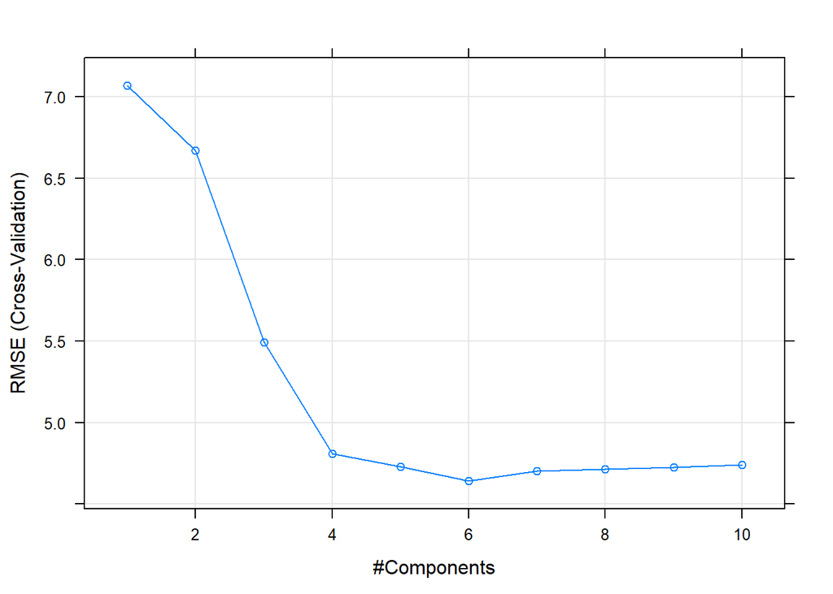

```
##   ncomp
## 6     6
```

```
## Data:    X dimension: 407 13
##  Y dimension: 407 1
## Fit method: svdpc
## Number of components considered: 6
## TRAINING: % variance explained
##           1 comps  2 comps  3 comps  4 comps  5 comps  6 comps
## X           46.74    58.20    68.07    74.89    80.84    85.68
## .outcome    38.16    45.83    63.81    71.69    72.48    73.58
```

```
##    ncomp     RMSE  Rsquared      MAE   RMSESD RsquaredSD     MAESD
## 1      1 7.069674 0.4108733 4.968888 1.428498 0.11612412 0.8321492
## 2      2 6.668627 0.4784994 4.920930 1.305530 0.09715125 0.8593685
## 3      3 5.492085 0.6554937 3.910267 1.076700 0.08584775 0.4960187
## 4      4 4.807309 0.7412902 3.410473 1.217845 0.10264549 0.5245772
## 5      5 4.730310 0.7485844 3.349186 1.180811 0.09518155 0.5392856
## 6      6 4.639857 0.7580017 3.259253 1.201486 0.09619215 0.6093420
## 7      7 4.703762 0.7519934 3.302859 1.175154 0.09101431 0.6043344
## 8      8 4.713770 0.7500609 3.307305 1.182643 0.09029929 0.6178116
## 9      9 4.725388 0.7484499 3.311028 1.177329 0.08901965 0.6166116
## 10    10 4.738671 0.7473791 3.346518 1.156378 0.08665496 0.6168442
```

```
##       RMSE   Rsquare
## 1 6.248853 0.5700468
```

- 95% confidence interval for RMSE

  | ncomp | RMSE | Rsquared | MAE | RMSESD | RsquaredSD | MAESD | Lower_interval | Upper_interval |
  | --- | --- | --- | --- | --- | --- | --- | --- | --- |
  | 1 | 7.069674 | 0.4108733 | 4.968888 | 1.428498 | 0.1161241 | 0.8321492 | 4.269818 | 9.869530 |
  | 2 | 6.668627 | 0.4784994 | 4.920930 | 1.305530 | 0.0971512 | 0.8593685 | 4.109789 | 9.227465 |
  | 3 | 5.492084 | 0.6554937 | 3.910267 | 1.076700 | 0.0858477 | 0.4960187 | 3.381753 | 7.602416 |
  | 4 | 4.807309 | 0.7412902 | 3.410473 | 1.217845 | 0.1026455 | 0.5245772 | 2.420332 | 7.194286 |
  | 5 | 4.730310 | 0.7485844 | 3.349186 | 1.180811 | 0.0951816 | 0.5392856 | 2.415921 | 7.044698 |
  | 6 | 4.639857 | 0.7580017 | 3.259253 | 1.201486 | 0.0961922 | 0.6093420 | 2.284945 | 6.994769 |
  | 7 | 4.703762 | 0.7519934 | 3.302859 | 1.175154 | 0.0910143 | 0.6043344 | 2.400460 | 7.007063 |
  | 8 | 4.713770 | 0.7500609 | 3.307305 | 1.182643 | 0.0902993 | 0.6178116 | 2.395791 | 7.031750 |
  | 9 | 4.725388 | 0.7484499 | 3.311028 | 1.177329 | 0.0890196 | 0.6166116 | 2.417824 | 7.032952 |
  | 10 | 4.738671 | 0.7473791 | 3.346518 | 1.156378 | 0.0866550 | 0.6168442 | 2.472169 | 7.005172 |

## 3.5 Partial least squares.

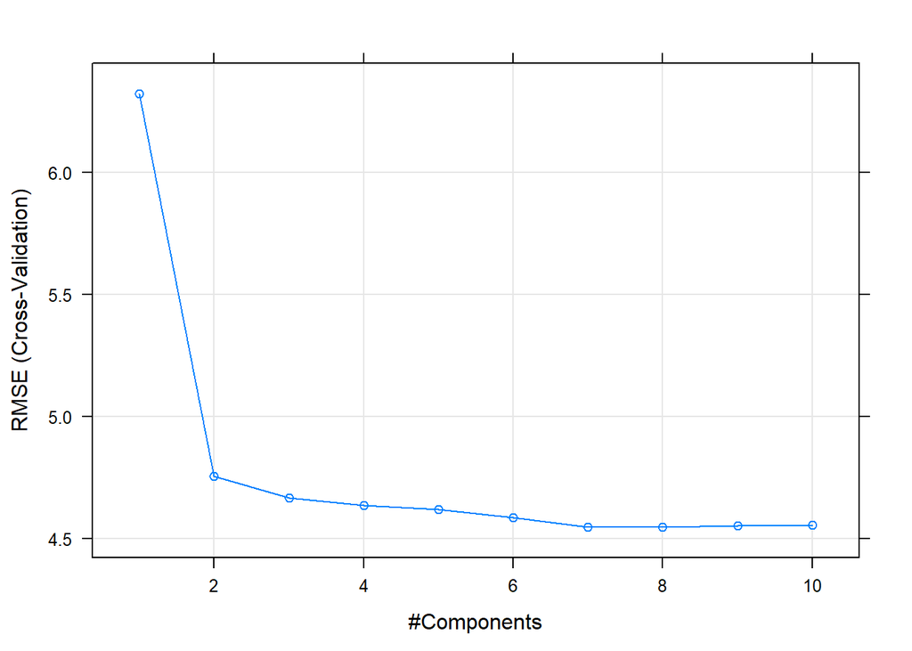

```r
modelPls <- train(medv~., data = train.data, method = "pls",
  scale = TRUE,trControl = trainControl("cv", number = 10),tuneLength = 10)

# Plot model RMSE vs different values of components
plot(modelPls)
```

```r
# Print the best tuning parameter ncomp that
# minimize the cross-validation error, RMSE
modelPls$bestTune
```

```
##   ncomp
## 8     8
```

```r
modelPls$results
```

```
##    ncomp     RMSE  Rsquared      MAE    RMSESD RsquaredSD     MAESD
## 1      1 6.322346 0.5357968 4.409140 1.0200355 0.07770934 0.5579864
## 2      2 4.755187 0.7369203 3.316153 0.9203550 0.10134081 0.4113357
## 3      3 4.667072 0.7508450 3.246255 0.8793737 0.08479099 0.3843212
## 4      4 4.636840 0.7557636 3.285237 0.8546889 0.08051181 0.4114188
## 5      5 4.619716 0.7564118 3.306686 0.7891552 0.07600220 0.4079974
## 6      6 4.587568 0.7596679 3.290683 0.7932726 0.07703199 0.3927342
## 7      7 4.548180 0.7633063 3.258920 0.7976268 0.07773089 0.4071205
## 8      8 4.547073 0.7633205 3.264285 0.8116339 0.07864493 0.4061916
## 9      9 4.554253 0.7626969 3.268637 0.8092572 0.07796418 0.4074597
## 10    10 4.555834 0.7625066 3.268298 0.8087676 0.07804868 0.4062492
```

```r
# Make predictions
predictions <- modelPls %>% predict(test.data)
# Model performance metrics
data.frame(
  RMSE = caret::RMSE(predictions, test.data$medv),
  Rsquare = caret::R2(predictions, test.data$medv)
)
```

```
##       RMSE   Rsquare
## 1 5.864738 0.6256077
```

- 95% Confidence intervals for RMSE

| ncomp | RMSE | Rsquared | MAE | RMSESD | RsquaredSD | MAESD | Lower_interval | Upper_interval |
| --- | --- | --- | --- | --- | --- | --- | --- | --- |
| 1 | 6.322346 | 0.5357968 | 4.409140 | 1.0200355 | 0.0777093 | 0.5579864 | 4.323076 | 8.321615 |
| 2 | 4.755187 | 0.7369203 | 3.316153 | 0.9203550 | 0.1013408 | 0.4113357 | 2.951291 | 6.559083 |
| 3 | 4.667072 | 0.7508450 | 3.246255 | 0.8793737 | 0.0847910 | 0.3843212 | 2.943499 | 6.390644 |
| 4 | 4.636840 | 0.7557636 | 3.285237 | 0.8546889 | 0.0805118 | 0.4114188 | 2.961650 | 6.312031 |
| 5 | 4.619716 | 0.7564118 | 3.306686 | 0.7891552 | 0.0760022 | 0.4079974 | 3.072972 | 6.166461 |
| 6 | 4.587568 | 0.7596679 | 3.290683 | 0.7932726 | 0.0770320 | 0.3927342 | 3.032754 | 6.142383 |
| 7 | 4.548180 | 0.7633063 | 3.258920 | 0.7976268 | 0.0777309 | 0.4071205 | 2.984832 | 6.111529 |
| 8 | 4.547073 | 0.7633205 | 3.264285 | 0.8116339 | 0.0786449 | 0.4061916 | 2.956271 | 6.137876 |
| 9 | 4.554253 | 0.7626969 | 3.268637 | 0.8092572 | 0.0779642 | 0.4074597 | 2.968109 | 6.140397 |
| 10 | 4.555834 | 0.7625066 | 3.268298 | 0.8087676 | 0.0780487 | 0.4062492 | 2.970649 | 6.141018 |

# 4 Discussion

The bias and standard error for `R-squared` is smaller suggesting to be a good measure for the model. R-squared upper and lower interval is close to the statistics(R-squared). i.e 0.7406427 has a 95% CI of `( 0.6753, 0.7819 )`

Because of overfitting variables of age and indus; bias, SE and wider CI for intercept we can explore other methods.

Stepwise regression shows that the best model is one excluding variable age and indus. This is evidence by their lower AIC of `Step: AIC=1585.76` best model is `medv ~ crim + zn + chas + nox + rm + dis + rad + tax + ptratio + black + lstat`. It worth mentioning that the Bootstrap Statistics; bias and Std error is *zero* which is not the case in an ideal data inquiry. Using the step function without boostrapping will lead us to the same conclusion as for multilinear model with the exclusion of age and indus predictors. See section 3.3

# 5 Conclusion

Base on the above statistical modelling “Partial least squares” is the best predictive models. Age and indus overfits the model and hence good to exclude them as modelled by step wise method. All the other variables explains the model without overfitting or underfitting.

# 6 References

https://www.statmethods.net/advstats/bootstrapping.html

An Introduction to Statistical Learning with Applications in R by Gareth James, Daniela Witten, Trevor Hastie and Robert Tibshirani